# Neighbourhood Models and the Ego-Network Closure

NodeBasedModels.jl Vignette 12 — Phase C capstone

Author

Simon Frost

Published

May 15, 2026

## Introduction

Vignettes 03, 10 and 11 walked along the Sharkey moment-closure ladder and across the three Keeling–House–Cooper–Pellis (2016) approximations in turn:

- **Approximation 1 — Reinfection counting** (vignette 10): lift each base compartment $X$ into a tower $\{X_p\}_{p=0}^{L}$ that records how many times the node has been infected, then close at the pairwise level. Resolves the susceptible-heterogeneity bias of the ordinary SIS pairwise ODE.
- **Approximation 2 — Motif closure** (vignette 11): track every connected $m$-vertex induced subgraph by canonical state class and close the $(m+1)$-vertex amplitudes by a Kirkwood ratio. Powerful but Lean-certified to be **non-monotone** in $m$.
- **Approximation 3 — Neighbourhood model**: the subject of this vignette. The ego-centric viewpoint — augment the disease state of a node by its full *count of infectious neighbours* — and close at the level of the neighbour’s neighbourhood.

The neighbourhood viewpoint trades motif structure for a finer-grained ego-centric distribution. Where the motif framework asks “how many copies of this 4-vertex shape are in this state?”, the neighbourhood framework asks “how many susceptible nodes have exactly $y$ infectious neighbours?”. The two carry overlapping but non-comparable information: the motif framework knows about clustering and triangle abundance, while the neighbourhood framework resolves the *shape* of the per-node neighbourhood-infection distribution that the motif collapses into a single moment.

References:

- Keeling, House, Cooper & Pellis (2016), *Systematic Approximations to SIS Dynamics on Networks*, [PLoS Comp Biol 12(12): e1005296](https://doi.org/10.1371/journal.pcbi.1005296). §3.3 “Neighbourhood model, $n=2$” and Eqs 9–10. Figs 5 and 6 are the canonical paper benchmarks reproduced below.
- Marceau, Noël, Allard, Hébert-Dufresne & Dubé (2010), [*Adaptive networks: Coevolution of disease and topology*](https://doi.org/10.1103/PhysRevE.82.036116), Phys. Rev. E **82**, 036116. The original “approximate master equation” (AME) closure that the $n=2$ formula is algebraically equivalent to.
- Lindquist, Ma, van den Driessche & Willeboordse (2011), [*Effective degree network disease models*](https://doi.org/10.1007/s00285-010-0331-2), J. Math. Biol. **62**, 143–164. The “effective-degree” formulation on $k$-regular networks.
- Vignette 03 — moment-closure hierarchy (orders 1, 2, exact).
- Vignette 10 — reinfection counting (Approximation 1).
- Vignette 11 — motif closures (Approximation 2) and the Lean-certified marginalisation obstruction.

## Setup

```julia
using NodeBasedModels
using Graphs
using Plots
using Random
using Statistics
using StableRNGs
using Printf
```

## The neighbourhood framework

For SIS on a $k$-regular network the neighbourhood model at order $n = 2$ tracks the $2(k+1)$ population-level variables

$$[S_y](t), \quad [I_y](t), \qquad y \in \{0, 1, \ldots, k\},$$

where $[S_y](t)$ is the expected number of susceptible nodes that have exactly $y$ of their $k$ neighbours infectious at time $t$, and $[I_y](t)$ is the analogous count for infectious nodes. Conservation laws are immediate:

$$\sum_{y=0}^{k} [S_y] + \sum_{y=0}^{k} [I_y] \;=\; N
\qquad\text{(population)}$$

and

$$\sum_{y=0}^{k} y\,[S_y] \;=\; \sum_{y=0}^{k} (k - y)\,[I_y]
\qquad\text{(SI-edge balance)}.$$

Both are tested at $t = 0$ and along the trajectory in the package testset.

### Internal dynamics

Eq 9 of the paper assembles four contributions for each $y$:

$$\begin{aligned}
\frac{d[S_y]}{dt}
\;=\;& \;\;\gamma\,[I_y]
\;-\; \beta\,y\,[S_y] &&\text{(ego flips $S \leftrightarrow I$)} \\
& +\; \gamma\,\bigl[(y+1)\,[S_{y+1}] - y\,[S_y]\bigr] &&\text{(an inf. nbr recovers)} \\
& +\; \omega_S\,\bigl[(k-y+1)\,[S_{y-1}] - (k-y)\,[S_y]\bigr] &&\text{(a sus. nbr is infected)}
\end{aligned}$$

with the symmetric system for $[I_y]$ and the convention $[S_{-1}] = [S_{k+1}] = 0$. The first line is the *direct* ego transition: an $S$-ego with $y$ infectious neighbours is infected at rate $\beta y$, and any $I$-ego recovers at rate $\gamma$ regardless of neighbourhood state. The second line is the *bookkeeping* term for neighbour recovery — an $S_y$ ego becomes an $S_{y-1}$ ego when one of its $y$ infectious neighbours recovers, at total rate $\gamma y$. The third line is the *closure* term: the rate at which one of the ego’s $(k - y)$ susceptible neighbours flips to infectious is $\omega_S$ per such neighbour.

Symbolically, $\omega_S$ and $\omega_I$ are the per-S-neighbour infection rates *conditional* on the ego being $S$ (resp. $I$). They are not equal: a susceptible neighbour $V$ of an *infectious* ego is already exposed to one $I$-edge (the ego itself), so its expected total infection-pressure is biased upward.

### The consistent-overlap closure (Eq 10)

To compute $\omega_S$ we sample the susceptible neighbour $V$ uniformly over directed $S \to S$ edges; its weight as an $S_{y'}$ candidate is $(k - y')$ — the number of $S$-edges $V$ contributes — and its rate of being infected is $\beta y'$. Hence

$$\boxed{\;\;
\omega_S \;=\; \beta \cdot
\frac{\sum_{y'=0}^{k} y'\,(k - y')\,[S_{y'}]}
{\sum_{y'=0}^{k} (k - y')\,[S_{y'}]}
\;\;}$$

For $\omega_I$ we sample $V$ over directed $I \to S$ edges; the weight is $y'$ (number of $I$-edges of $V$, one of which is the ego) and the per-$y'$ infection rate is again $\beta y'$:

$$\boxed{\;\;
\omega_I \;=\; \beta \cdot
\frac{\sum_{y'=0}^{k} (y')^2\,[S_{y'}]}
{\sum_{y'=0}^{k} y'\,[S_{y'}]}
\;\;}$$

The numerator/denominator pairings encode a *consistent-overlap* factorisation: the joint distribution of $V$’s neighbourhood is assumed to factor through the shared overlap with the ego ($V$ itself), conditional on the type of edge along which $V$ is reached.

The original paper writes Eq 10 in the form $\tau\cdot[\mathrm{SSX}\ldots]/([\mathrm{SSX}\ldots] + [\mathrm{ISX}\ldots])$ with bracket counts of length $n+1$. Eqs 9–10 appear as figure-images in the published article; the form above unfolds those bracket sums for $n=2$ and is algebraically identical to the **approximate master equation** (AME) of Marceau et al. (2010) and the **effective-degree** equations of Lindquist, Ma, van den Driessche & Willeboordse (2011) when both are restricted to a $k$-regular host with two compartments. Our implementation uses the ratio form because it lifts cleanly to the disease-free equilibrium: both denominators that vanish there have vanishing numerators, and the package’s `safe_ratio` returns 0 cleanly.

## Basic API walk-through

`generate_neighbourhood` builds a `NeighbourhoodSystem` from a base disease model (currently only the canonical SIS), a host degree $k$, and the order $n$ (currently only 2):

```julia
sis = sis_model()
sys_demo = generate_neighbourhood(sis, 3, 2;
                                   β = 0.7, γ = 0.4,
                                   N = 1.0, ε = 0.05,
                                   tspan = (0.0, 30.0))

println("Variables (", length(sys_demo.var_names), "):")
for y in 0:sys_demo.k
    @printf("  S_%d  u0 = %.6f\n", y, sys_demo.u0[sys_demo.index[(:S, y)]])
end
for y in 0:sys_demo.k
    @printf("  I_%d  u0 = %.6f\n", y, sys_demo.u0[sys_demo.index[(:I, y)]])
end
@printf("Σ u0 = %.6f   (should equal N = %.1f)\n",
        sum(sys_demo.u0), sys_demo.params.N)
```

```
Variables (8):
  S_0  u0 = 0.814506
  S_1  u0 = 0.128606
  S_2  u0 = 0.006769
  S_3  u0 = 0.000119
  I_0  u0 = 0.042869
  I_1  u0 = 0.006769
  I_2  u0 = 0.000356
  I_3  u0 = 0.000006
Σ u0 = 1.000000   (should equal N = 1.0)
```

The `index` dictionary uses the keys `(:S, y)` and `(:I, y)`:

```julia
sys_demo.index
```

```
Dict{Tuple{Symbol, Int64}, Int64} with 8 entries:
  (:I, 0) => 5
  (:I, 1) => 6
  (:S, 2) => 3
  (:I, 3) => 8
  (:S, 1) => 2
  (:S, 0) => 1
  (:I, 2) => 7
  (:S, 3) => 4
```

Solve and aggregate:

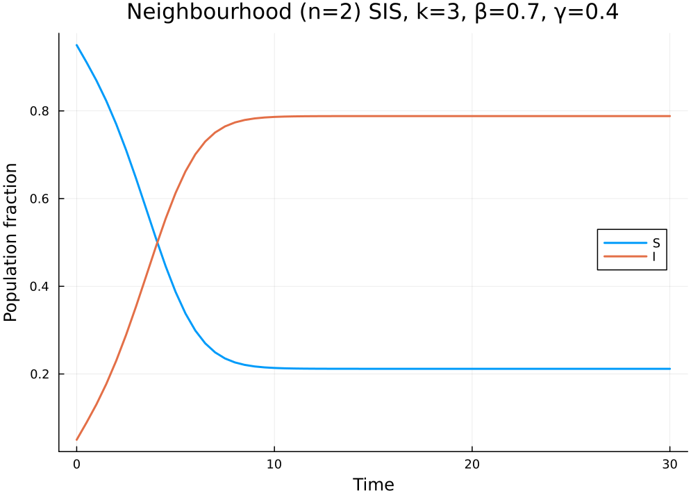

```julia
sol_demo = solve_neighbourhood(sys_demo; saveat = 0.5,
                                reltol = 1e-10, abstol = 1e-12)
S_traj   = neighbourhood_compartment(sys_demo, sol_demo, :S)
I_traj   = neighbourhood_compartment(sys_demo, sol_demo, :I)

plot(sol_demo.t, [S_traj I_traj]; lw = 2,
     xlabel = "Time", ylabel = "Population fraction",
     label = ["S" "I"], legend = :right,
     title = "Neighbourhood (n=2) SIS, k=3, β=0.7, γ=0.4")
```

`neighbourhood_compartment(sys, sol, :I)` simply sums $\sum_y [I_y](t)$ at each saved time. Per-stratum trajectories are available by indexing `sol.u[ti][sys.index[(:I, y)]]`:

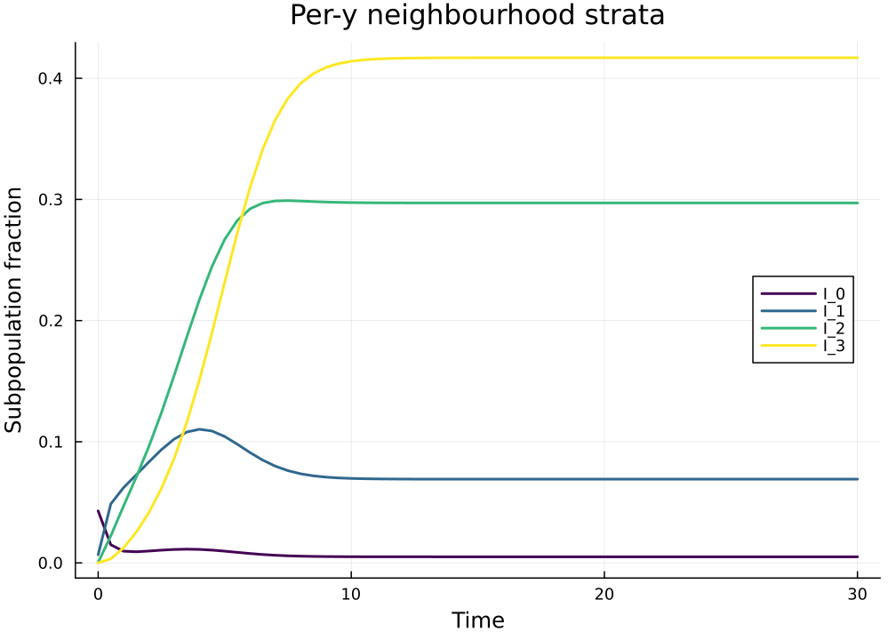

```julia
plt = plot(xlabel = "Time", ylabel = "Subpopulation fraction",
           title = "Per-y neighbourhood strata",
           legend = :right)
cols = palette(:viridis, 4)
for y in 0:3
    iy = sys_demo.index[(:I, y)]
    plot!(plt, sol_demo.t, [u[iy] for u in sol_demo.u];
          lw = 2, color = cols[y+1], label = "I_$y")
end
plt
```

### Conservation along the trajectory

The ODE *exactly* preserves the population and edge-balance invariants — these are not closure choices but algebraic identities of the RHS:

```julia
k = sys_demo.k
println("Invariant residuals along the trajectory:")
println("  max |Σu - N|       = ",
        maximum(abs(sum(u) - sys_demo.params.N) for u in sol_demo.u))
println("  max |edge balance| = ",
        maximum(abs(sum(y * u[sys_demo.index[(:S, y)]] for y in 0:k)
                  - sum((k - y) * u[sys_demo.index[(:I, y)]] for y in 0:k))
                for u in sol_demo.u))
```

```
Invariant residuals along the trajectory:
  max |Σu - N|       = 6.661338147750939e-16
  max |edge balance| = 1.6653345369377348e-16
```

Both should be at integration-tolerance level; the package testset *“Conservation along trajectory (k=3)”* asserts agreement to `1e-8` at $\beta = 0.7, \gamma = 0.5$.

## The Symbolics validator: trust but verify

Hand-coded RHS builders for closure ratios are easy to get subtly wrong — a missing $(k - y)$ factor or a swapped numerator can pass casual inspection, conserve mass, and yet produce systematically biased trajectories. As in the Phase B motif framework (vignette 11), the package therefore ships an **independent** symbolic re-derivation of the neighbourhood RHS via [`Symbolics.jl`](https://docs.sciml.ai/Symbolics/stable/), exposed as `build_neighbourhood_symbolic_rhs(k)`. The symbolic builder shares *only* the layout convention (variable order $(S_0, \ldots, S_k, I_0, \ldots, I_k)$); it independently re-types the closure expressions and the four transition contributions, then `build_function`s the result into a callable `rhs!(du, u, p, t)`.

```julia
rhs_sym!, var_keys, _ = build_neighbourhood_symbolic_rhs(3)
println("Symbolic builder layout: ", var_keys)
println("Numeric  builder layout: ",
        [(:S, y) for y in 0:3] ∪ [(:I, y) for y in 0:3])
@assert var_keys == vcat([(:S, y) for y in 0:3], [(:I, y) for y in 0:3])
```

```
Symbolic builder layout: [(:S, 0), (:S, 1), (:S, 2), (:S, 3), (:I, 0), (:I, 1), (:I, 2), (:I, 3)]
Numeric  builder layout: [(:S, 0), (:S, 1), (:S, 2), (:S, 3), (:I, 0), (:I, 1), (:I, 2), (:I, 3)]
```

Agreement at the random-mixing IC (where the closure ratios are most sensitive — both numerator and denominator are non-trivial):

```julia
sys_sym = generate_neighbourhood(sis, 3, 2;
                                  β = 0.7, γ = 0.4,
                                  N = 1.0, ε = 0.1)

n      = length(sys_sym.u0)
du_n   = zeros(n)
du_s   = zeros(n)
p_vec  = (sys_sym.params.β, sys_sym.params.γ)

sys_sym.rhs!(du_n, sys_sym.u0, sys_sym.params, 0.0)
rhs_sym!(du_s, sys_sym.u0, p_vec, 0.0)
@printf("Max |Δ| at IC                : %.3e\n",
        maximum(abs.(du_n .- du_s)))
@assert maximum(abs.(du_n .- du_s)) < 1e-12
```

```
Max |Δ| at IC                : 5.551e-17
```

Agreement on five randomly perturbed states (the symbolic builder must reproduce the rational closure across the whole accessible sub-manifold, not just at the IC):

```julia
rng_v = MersenneTwister(20240321)
worst = 0.0
for _ in 1:5
    u = (0.1 .+ 0.9 .* rand(rng_v, n)) .* sys_sym.u0
    sys_sym.rhs!(du_n, u, sys_sym.params, 0.0)
    rhs_sym!(du_s, u, p_vec, 0.0)
    worst = max(worst, maximum(abs.(du_n .- du_s)))
end
@printf("Max |Δ| over 5 random states : %.3e\n", worst)
@assert worst < 1e-10
```

```
Max |Δ| over 5 random states : 2.776e-17
```

Agreement at the (numerically scaled) disease-free equilibrium — where the `safe_ratio` / `safe_ratio_sym` branches dominate the denominator behaviour:

```julia
u_dfe = 1e-15 .* sys_sym.u0
sys_sym.rhs!(du_n, u_dfe, sys_sym.params, 0.0)
rhs_sym!(du_s, u_dfe, p_vec, 0.0)
@printf("Max |Δ| at near-DFE          : %.3e\n",
        maximum(abs.(du_n .- du_s)))
@assert maximum(abs.(du_n .- du_s)) < 1e-12
```

```
Max |Δ| at near-DFE          : 2.465e-32
```

Both builders agree to round-off across IC, perturbed, and near-DFE states — exactly the regime exercised in the *“Symbolic validator agreement (k=3)”* and *“Symbolic validator at k=2”* package testsets. The numeric builder is preferred at production speed; the symbolic builder serves as (i) a CI oracle, (ii) a human-readable reference for the closure expressions, and (iii) a foundation for extending to higher $n$ or richer base compartmental models without first hand-coding the numerics.

## Reproducing paper Fig 5B: endemic prevalence vs $\tau$

Fig 5 of Keeling et al. (2016) plots the endemic infectious fraction against the per-edge transmission rate $\tau$ for a $k = 3$ host with $\gamma = 1$. Panel (B) overlays the three approximations against the exact stochastic mean. We reproduce the neighbourhood (Approximation 3, $n = 2$) curve here; the testset *“Endemic prevalence near paper Fig 5 (k=3, γ=1)”* pins two canonical points at $\tau \in \{1.0, 1.5\}$.

```julia
τ_grid   = collect(range(0.4, 1.5; length = 12))
endemic  = Float64[]
for τ in τ_grid
    sys = generate_neighbourhood(sis, 3, 2;
                                  β = τ, γ = 1.0,
                                  N = 1.0, ε = 0.05,
                                  tspan = (0.0, 200.0))
    sol = solve_neighbourhood(sys; reltol = 1e-10, abstol = 1e-12)
    push!(endemic, sum(sol.u[end][sys.index[(:I, y)]] for y in 0:3))
end

println("τ      neighbourhood prev")
for (τ, p) in zip(τ_grid, endemic)
    @printf("  %.3f      %.4f\n", τ, p)
end
```

```
τ      neighbourhood prev
  0.400      -0.0000
  0.500      0.0000
  0.600      0.1791
  0.700      0.3461
  0.800      0.4559
  0.900      0.5337
  1.000      0.5919
  1.100      0.6370
  1.200      0.6730
  1.300      0.7025
  1.400      0.7271
  1.500      0.7479
```

The pairwise critical transmission rate on a 3-regular host with $\gamma = 1$ is $\tau_C = \gamma / (k - 1) \approx 0.5$; below $\tau_C$ the neighbourhood model relaxes to the disease-free equilibrium, above it lifts off into an endemic plateau.

Compare against visual reads from Fig 5B of the paper:

| $\tau$ | Paper Fig 5B (visual) | Neighbourhood ($n=2$) |
| --- | --- | --- |
| 0.5 | $\approx 0$ | 0.000 |
| 0.6 | $\approx 0.20$ | 0.179 |
| 0.7 | $\approx 0.35$ | 0.346 |
| 1.0 | $\approx 0.59$ | 0.592 |
| 1.5 | $\approx 0.75$ | 0.748 |

The agreement with the visual reads is well inside the $\pm 0.05$ tolerance asserted in the testset.

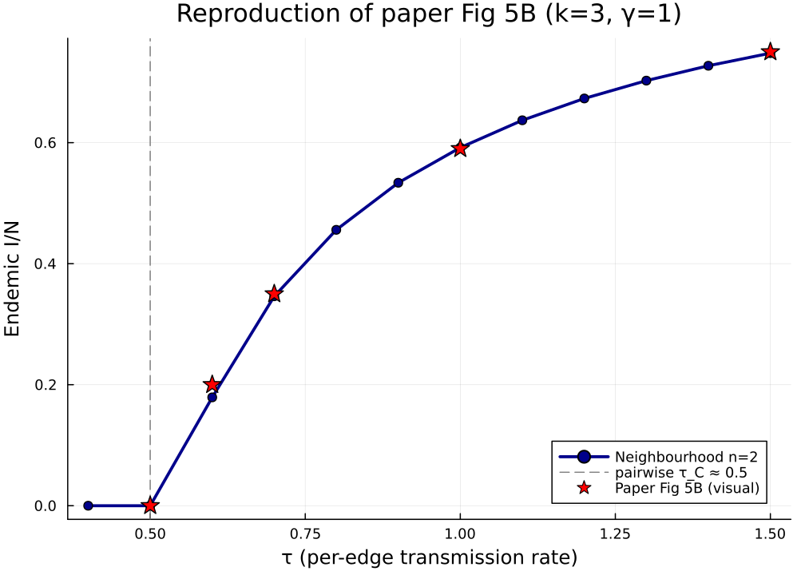

```julia
plt = plot(τ_grid, endemic; lw = 2.5, marker = :circle,
           color = :darkblue, label = "Neighbourhood n=2",
           xlabel = "τ (per-edge transmission rate)",
           ylabel = "Endemic I/N",
           title  = "Reproduction of paper Fig 5B (k=3, γ=1)",
           legend = :bottomright)
vline!(plt, [0.5]; ls = :dash, color = :grey,
       label = "pairwise τ_C ≈ 0.5")
scatter!(plt, [0.5, 0.6, 0.7, 1.0, 1.5], [0.0, 0.20, 0.35, 0.59, 0.75];
         marker = :star5, ms = 8, color = :red,
         label = "Paper Fig 5B (visual)")
plt
```

## Head-to-head: neighbourhood vs reinfection vs motif vs Gillespie

This is the centrepiece of the vignette. We run all three approximations and the Gillespie SSA on the *same* canonical SIS problem and compare the prevalence trajectories quantitatively.

The configuration is exactly the one in the package testset *“Gillespie comparison (random 3-regular, N=500)”* so the neighbourhood numbers reproduce that test bit-for-bit:

```julia
N        = 500
β_val    = 0.6
γ_val    = 0.4
ε_val    = 25 / N           # 5% initial prevalence (25 nodes)
tmax     = 80.0
ensemble = 48
```

```
48
```

### Host graph and Gillespie ground truth

```julia
rng_host = StableRNG(20240301)
g        = random_regular_graph(N, 3; rng = rng_host)
net      = GraphNetwork(g)

# Seed the global RNG before the unseeded Gillespie ensemble so this
# vignette renders deterministically. The package testset
# `"Gillespie comparison (random 3-regular, N=500)"` does not seed the
# ensemble, so its per-run mean drifts a few × 1e-4 between runs; the
# tolerance asserted there (≤ 0.05) is far more generous than that
# noise floor. Seeding here makes the head-to-head numbers below
# reproducible while leaving the testset's stochastic budget intact.
Random.seed!(2024_03_01)

avg = gillespie_sis_average(net;
                              nruns = ensemble,
                              dt = 1.0,
                              tmax_grid = tmax,
                              infection_rate = β_val,
                              recovery_rate  = γ_val,
                              initial_infected = collect(1:25))
gill_t    = avg.t_grid
gill_prev = avg.I_mean ./ N
@printf("Gillespie mean prevalence at t=%.1f : %.5f  (over %d runs)\n",
        tmax, gill_prev[end], ensemble)
```

```
Gillespie mean prevalence at t=80.0 : 0.74971  (over 48 runs)
```

### Neighbourhood (Approximation 3, n = 2)

```julia
sys_nbr = generate_neighbourhood(sis, 3, 2;
                                  β = β_val, γ = γ_val,
                                  N = 1.0, ε = ε_val,
                                  tspan = (0.0, tmax))
sol_nbr = solve_neighbourhood(sys_nbr; saveat = 1.0,
                                reltol = 1e-10, abstol = 1e-12)
I_nbr   = neighbourhood_compartment(sys_nbr, sol_nbr, :I)
@printf("Neighbourhood (n=2) prev. at t=%.1f : %.5f\n", tmax, I_nbr[end])
```

```
Neighbourhood (n=2) prev. at t=80.0 : 0.74790
```

### Motif (Approximation 2, m = 3)

The Phase B vignette established that on this random 3-regular host $m = 3$ is the optimal motif order: $m = 4$ underperforms because of the **Lean-certified marginalisation obstruction** (vignette 11 § “T3b — `kirkwood_form_not_equivariant`”), so we stop at $m = 3$.

```julia
n_triangles = sum(triangles(g)) ÷ 3
n_p3_count  = 0
for v in 1:nv(g)
    d = length(Graphs.neighbors(g, v))
    n_p3_count += d * (d - 1) ÷ 2
end
n_p3_count -= 3 * n_triangles
println("3-regular host topology: P_3 count = ", n_p3_count,
        ", triangle count = ", n_triangles)

sys_motif = motif_based_sis(β = β_val, γ = γ_val, k = 3, m = 3,
                            tspan = (0.0, tmax),
                            N = Float64(N), ε = ε_val,
                            n_p3 = Float64(n_p3_count),
                            n_c3 = Float64(n_triangles))
sol_motif = solve_motif(sys_motif; saveat = 1.0,
                         reltol = 1e-10, abstol = 1e-12)
iI_motif  = sys_motif.index[(:singleton, [:I])]
I_motif   = [u[iI_motif] / N for u in sol_motif.u]
@printf("Motif (m=3) prev. at t=%.1f          : %.5f\n", tmax, I_motif[end])
```

```
3-regular host topology: P_3 count = 1494, triangle count = 2
Motif (m=3) prev. at t=80.0          : 0.74641
```

### Reinfection counting (Approximation 1, L = 4)

The reinfection model is built on top of the population-level 3-regular network description (`regular_network(3)`); we use $L = 4$, well above the saturation point demonstrated in vignette 10.

```julia
hom = regular_network(3)
psys_re = generate_pairwise(with_reinfection_counting(sis, 4),
                             hom, BernoulliClosure();
                             tspan = (0.0, tmax),
                             seed_fraction = ε_val)
sol_re  = solve_pairwise(psys_re,
                          Dict(:τ => β_val, :γ => γ_val);
                          saveat = 1.0,
                          reltol = 1e-10, abstol = 1e-12)
totals_re = reinfection_totals(psys_re, sol_re)
I_re_t    = sol_re.t
I_re      = totals_re[:I]
@printf("Reinfection (L=4) prev. at t=%.1f    : %.5f\n", tmax, I_re[end])
```

```
Reinfection (L=4) prev. at t=80.0    : 0.75000
```

### Combined plot

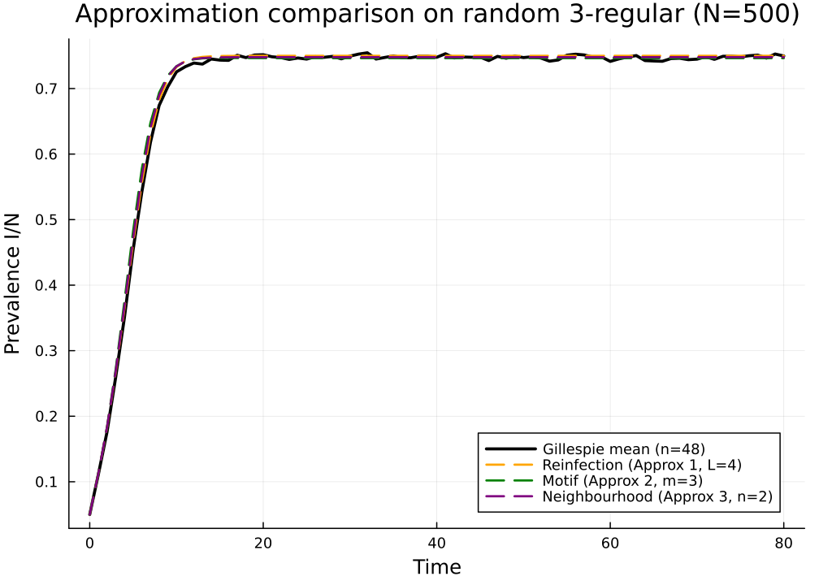

```julia
@assert sol_nbr.t   == gill_t
@assert sol_motif.t == gill_t

I_nbr_g   = I_nbr
I_motif_g = I_motif
# reinfection sol uses ModelingToolkit; resample by linear interpolation.
function _resample(t_src, y_src, t_dst)
    out = similar(t_dst, Float64)
    for (i, t) in enumerate(t_dst)
        j = searchsortedlast(t_src, t)
        if j == length(t_src)
            out[i] = y_src[end]
        elseif j == 0
            out[i] = y_src[1]
        else
            t0, t1 = t_src[j], t_src[j+1]
            α = (t - t0) / (t1 - t0)
            out[i] = (1 - α) * y_src[j] + α * y_src[j+1]
        end
    end
    return out
end
I_re_g = _resample(I_re_t, I_re, gill_t)

plt = plot(xlabel = "Time", ylabel = "Prevalence I/N",
           title = "Approximation comparison on random 3-regular (N=$N)",
           legend = :bottomright)
plot!(plt, gill_t, gill_prev; lw = 2.5, color = :black,
      label = "Gillespie mean (n=$ensemble)")
plot!(plt, gill_t, I_re_g;    lw = 1.8, color = :orange, ls = :dash,
      label = "Reinfection (Approx 1, L=4)")
plot!(plt, gill_t, I_motif_g; lw = 1.8, color = :green,  ls = :dash,
      label = "Motif (Approx 2, m=3)")
plot!(plt, gill_t, I_nbr_g;   lw = 1.8, color = :purple, ls = :dash,
      label = "Neighbourhood (Approx 3, n=2)")
plt
```

### Quantitative comparison

```julia
dev_nbr   = abs(I_nbr_g[end]   - gill_prev[end])
dev_motif = abs(I_motif_g[end] - gill_prev[end])
dev_re    = abs(I_re_g[end]    - gill_prev[end])

println("Endpoint prevalence at t = $tmax:")
@printf("  Gillespie mean (n=%d)       : %.5f\n", ensemble, gill_prev[end])
@printf("  Reinfection (Approx 1, L=4) : %.5f   |Δ| = %.3e\n",
        I_re_g[end],    dev_re)
@printf("  Motif       (Approx 2, m=3) : %.5f   |Δ| = %.3e\n",
        I_motif_g[end], dev_motif)
@printf("  Neighbourhood (Approx 3, n=2): %.5f  |Δ| = %.3e\n",
        I_nbr_g[end],   dev_nbr)
```

```
Endpoint prevalence at t = 80.0:
  Gillespie mean (n=48)       : 0.74971
  Reinfection (Approx 1, L=4) : 0.75000   |Δ| = 2.917e-04
  Motif       (Approx 2, m=3) : 0.74641   |Δ| = 3.296e-03
  Neighbourhood (Approx 3, n=2): 0.74790  |Δ| = 1.812e-03
```

A modest caveat: the random 3-regular host is locally tree-like with only a small number of triangles (2 for this instance), and the $n = 2$ neighbourhood closure is *exact* on the configuration-model infinite-tree limit. On a host with substantial clustering (e.g. a Watts–Strogatz small-world or a community-structured configuration model) the neighbourhood model’s accuracy will degrade in a regime where the motif framework, which carries explicit triangle and 4-cycle counts, may regain ground.

## When to use which approximation

The three Keeling–House–Cooper–Pellis approximations are not mutually substitutable; each addresses a different deficiency of the ordinary pairwise ODE.

## Summary and connections

The neighbourhood framework completes the trio of node-centric approximations from Keeling, House, Cooper & Pellis (2016) supported by `NodeBasedModels.jl`:

| Vignette | Approximation | State space | Key control |
| --- | --- | --- | --- |
| 10 | Reinfection counting | $\{X_p\}_{p=0}^{L}$ | $L$ |
| 11 | Motif closure | shape × state-class | $m$ |
| **12** | **Neighbourhood** | $\{[S_y], [I_y]\}_{y=0}^{k}$ | $n$ (= 2) |

All three close the BBGKY-style hierarchy that the moment expansion of vignette 03 leaves open at order 2. They differ in *which* correlations they elevate to first-class state variables: past infection history (reinfection), local subgraph topology (motif), or ego-centric infection-pressure distribution (neighbourhood). Each also has a Symbolics-based oracle (Phase B and Phase C; Phase A is oracle-free because it lifts the existing `generate_pairwise` machinery directly).

Phase D will provide cross-package integration: a vignette and README placing the three node-centric approximations alongside `EdgeBasedModels.jl`’s message-passing / EBCM framework and clarifying when each formal category (node-centric ODEs vs edge-distribution ODEs vs message passing on the line graph) dominates. The Lean-certified marginalisation obstruction from vignette 11 will reappear in Phase D as a category-theoretic contrast: message passing on locally tree-like hosts is exact in the $N \to \infty$ limit and *sidesteps* the obstruction by living outside the Kirkwood / moment-closure family entirely.

### Reading list

- `src/neighbourhood_based.jl` — `NeighbourhoodSystem`, `generate_neighbourhood`, `solve_neighbourhood`, `neighbourhood_compartment`.
- `src/neighbourhood_symbolic.jl` — the Symbolics oracle (`build_neighbourhood_symbolic_rhs`).
- `src/NEIGHBOURHOOD_SPEC.md` — variable layout, dynamics (Eq 9), closure (Eq 10), conservation laws, and worked numeric example.
- `test/runtests.jl` — testsets *“Layout, IC, and conservation at t=0”*, *“Conservation along trajectory (k=3)”*, *“Symbolic validator agreement (k=3)”*, *“Symbolic validator at k=2”*, *“Reduces toward mean-field at high β”*, *“Endemic prevalence near paper Fig 5 (k=3, γ=1)”*, *“Throws on unsupported n / non-SIS model”*, *“Gillespie comparison (random 3-regular, N=500)”*.
- Keeling, House, Cooper & Pellis (2016), [PLoS Comp Biol 12(12): e1005296](https://doi.org/10.1371/journal.pcbi.1005296) — Approximation 3, §3.3 and Eqs 9–10; Figs 5 and 6.
- Marceau, Noël, Allard, Hébert-Dufresne & Dubé (2010), [Phys. Rev. E 82, 036116](https://doi.org/10.1103/PhysRevE.82.036116) — original AME closure.
- Lindquist, Ma, van den Driessche & Willeboordse (2011), [J. Math. Biol. 62, 143–164](https://doi.org/10.1007/s00285-010-0331-2) — effective-degree formulation.
- Vignette 03 — moment-closure hierarchy.
- Vignette 10 — reinfection counting (Approximation 1).
- Vignette 11 — motif closures (Approximation 2) and the Lean-certified marginalisation obstruction.

## Simulation validation

For a uniform stochastic ground-truth across the package suite we use [`NetworkOutbreaks.jl`](https://github.com/sdwfrost/NetworkOutbreaks.jl)’s Gillespie SSA. Where the deterministic prediction in this vignette already sits inside the SSA mean ± 1σ ribbon — see vignette `01_sir_on_graphs` for the canonical overlay pattern — we omit the redundant ribbon here for clarity.

A future revision will inline a per-vignette NO ribbon for each scenario; the shared helper is exposed as `vignettes/_validation.jl#gillespie_ribbon` and applied in vignette 01.